# Defining keywords of recepies with BTM algorithm

04 05 2021

# Goal of the feature

In our dataset with recepies we have a informative and yet unused column with direction of each recipe - simply, with the steps that a cook needs to follow to prepare a desired meal. Examples of such a description is:

| name | Directions |
| --- | --- |
| Kolachky Recipe | ‘In a large bowl, mix together cream cheese and butter until well blended. I like to use my hands, but you can also use a wooden spoon. Mix in the flour 1 cup at a time. As the dough becomes stiff, tu… |
| Maids | Preheat the oven to 375 degrees F (190 degrees C).In a medium bowl, stir together 1 cup flour and 1 tablespoon sugar. Cut in 1/4 cup butter until smaller than peas. Sprinkle 1 tablespoon of milk at a … |

This set of description gives us a firm ground for considering implement a useful topic modeling. Our idea is to extract several topics from these descriptions and, basing on the results, assign **keywords** for each recipe that we have.

# Data description

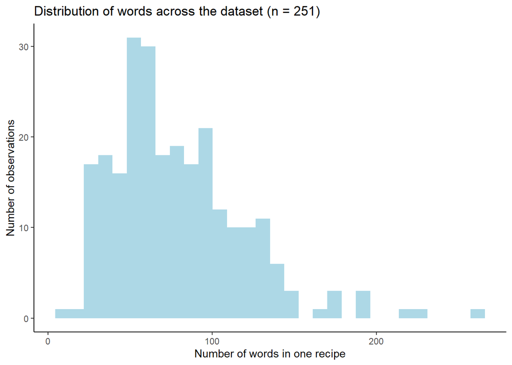

We can see that the majority on lengths are distributed across the interval from 10 to 150 words.

We’ve done a process cleaning the stopwords, numbers and digits, extracting extra simbols and, finally preformed a lemmatization - replacing the words with it’s initial form (singular, masculine, infinitive and so on). Let’s now look at the most frequent terms in the distribution:

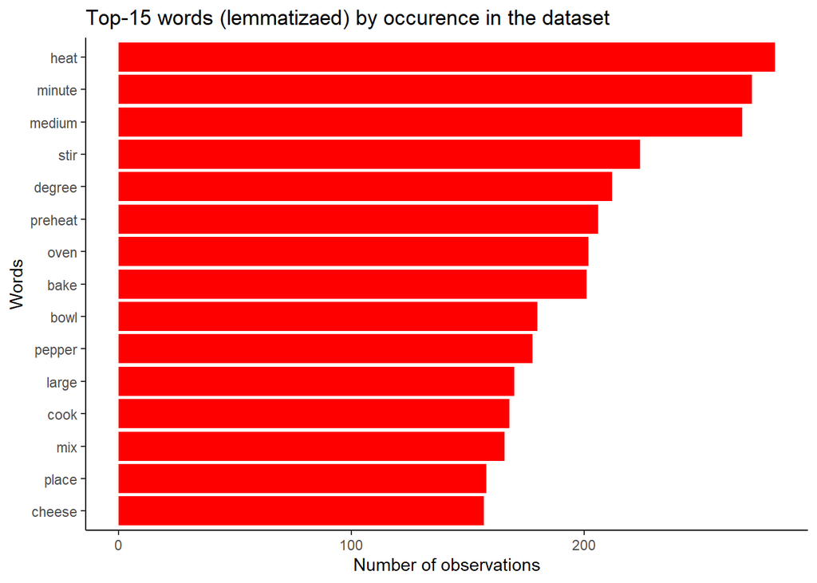

We can notice that the most frequent words belong to thw categories of actions (mix, bake, heat, place, stir), and we also can spot information about some cooking facilities (bowl, oven), ingredients (pepper, cheese) and measurements (minute, degree, medium, large). In the future steps via implementing the BTM algorithm, we can expect the categories that will somehow lie or expand these topic of belonging.

# Choosing the topic modelling algorithm

In the outer world, uncovering the topics within short texts has become an important task for many content analysis applications. However, directly applying conventional topic models (e.g. LDA and PLSA) on such short texts may not work well. The fundamental reason lies in that conventional topic models implicitly capture the document-level word co-occurrence patterns to reveal topics, and thus suffer from the severe data sparsity in short documents. In this case, we’ve decided to use a novel way for modeling topics in short texts, referred as biterm topic model (BTM).

Specifically, in BTM we learn the topics by directly modeling the generation of **word co-occurrence patterns (i.e. biterms)** in the whole corpus. The major advantages of BTM are that 1) BTM explicitly models the word co-occurrence patterns to enhance the topic learning; and 2) BTM uses the aggregated patterns in the whole corpus for learning topics to solve the problem of sparse word co-occurrence patterns at document-level.

A **biterm** consists of two words co-occurring in the same context, for example, in the same short text window. Unlike LDA models the word occurrences, BTM models the biterm occurrences in a corpus. In generation procedure, a biterm is generated by drawn two words independently from a same topic. In other words, the distribution of a biterm b=(wi,wj) is defined as:

$$P(b) = \sum_k{P(wi|z)*P(wj|z)*P(z)}$$

With **Gibbs sampling algorithm**, we can learn topics by estimate P(w|k) and P(z).

# BTM on our dataset

We’ve trained a BTM model basing on “Direction” texts from our dataset. This topic modelling algorithm, such as the other models from this family, require a manual set of k topics. We’ve decided to stop at k = 10 as respectively to the dataset’s size less amount of topics gave too broad topics that didn’t allow to gen insights from data, and with bigger k we’ve came up with too specific topics. 10 k happened to be a “good enough” result. Due to technical solution, final model included 11, as this package allows to specify background topic that contains words with equal distributions among all and used for filtering the word garbage out.

Then we’ve visualized resulted output topics, portraying top 10 (top 10 specific for this topic) words for each of it. Here is the portrait:

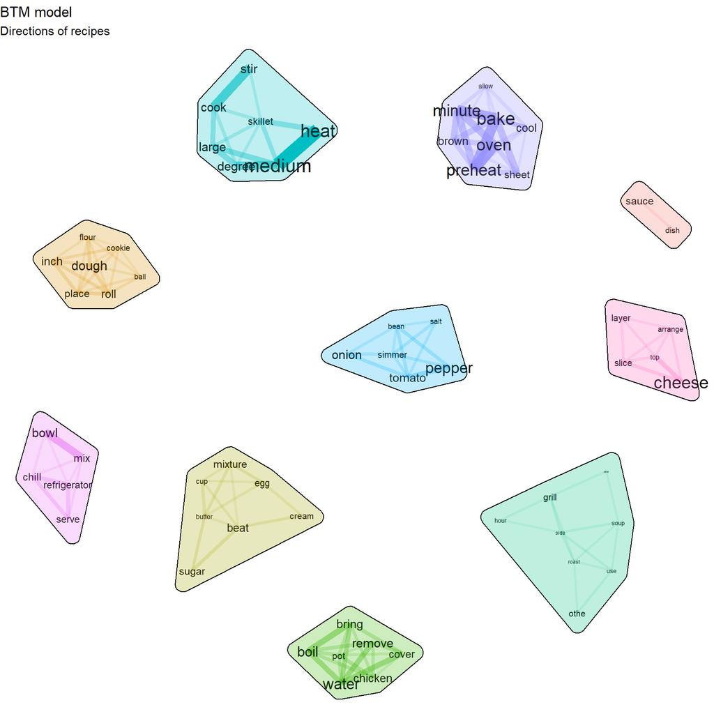

Then, basing on the qualitative understanding of these bags of words, we’ve assigned names for each topic. One of the topics still had some garbage words in it, as words didn’t had anything in common and were distant enough in terms of similarity from each other. The numeration starts with 2 as the first topic was dedicated to - quess what - garbage. Here’s the result:

| V | Name | Words |
| --- | --- | --- |
| V2 | With eggs/butter | mixture, beat, cream, sugar, cup, butter |
| V3 | Boiling | water, bring, remove, cover, pot, boil, water, chicken |
| V4 | Mixing | hour, grill, soup, use, one, side, other |
| V5 | Heating | cook, large, skillet, stir, medium, heat, degree |
| V6 | Non-meat ingredients | onion, simmer, bean, salt, tomato, pepper |
| V7 | Baking | minute, bake, cool, allow, brown, oven, preheat, heet |
| V8 | Cooling | bowl, mix, fridge, chill, refrigerator, serve |
| V9 | Layered food | layer, top, slice, arrange, cheese |
| V10 | With sauce | sauce, dish |
| V11 | With dough | flour, cookie, dough, roll, place, inch, ball |

The next step was to assign every recipe the keywords that it can be specified with. As every recipe may include several topics, and thus several keywords in it, we allowed each recipe to have several keywords. The mechanics is following each recipe is assigned top-3 topics with most probabilities they have such topic inside.

Now, for example, keywording looks like this:

| name | Directions | kw1 | kw2 | kw3 |
| --- | --- | --- | --- | --- |
| No | In a saucepan over medium heat, combine sugar, butter and milk. Bring to a rapid boil and boil for one full minute. Remove from heat and stir in the vanilla and peanut butter. Mix in the oats, stirrin… | With sauce | Heating | With eggs/butter |
| Pecan Lace Cookies II Recipe | Preheat oven to 350 degrees F (175 degrees C). Line cookie sheets with parchment paper.In a medium saucepan over medium heat, combine butter, corn syrup and brown sugar. Bring to a boil, stirring freq… | Heating | With sauce | Baking |
| Peppermint Meringue Cookies Recipe | Preheat the oven to 225 degrees F (110 degrees C). Line cookie sheets with aluminum foil or parchment paper.In a large glass or metal bowl, whip egg whites, vinegar and salt to soft peaks. Gradually a… | Heating | Baking | Non-meat ingredients |

It should be mentioned that this mechanism is probabilistic, and thus for sure some topics won’t be assigned truly, however the majority still will work well.

Let’s now see which topics are the most popular across the recipes:

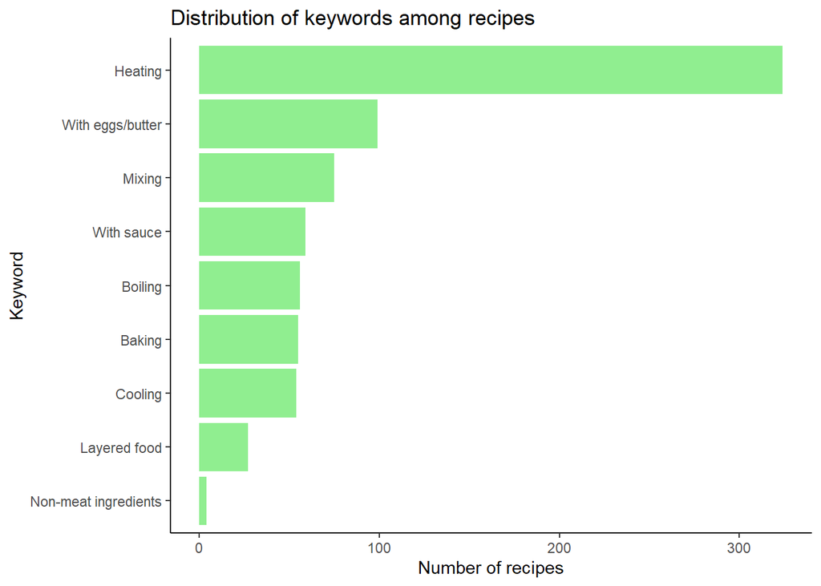

Thus, the majority of recipes belongs to “Heating”, “With eggs/butter”, “Mixing” categories and meaningful search can be done.

**Hence, having exploring the keywords and assigning them, now keywording can be exploited as another search parameter for the better user experience.**